```python
from IPython.core.display import HTML

def css_styling():
    styles = open("../styles/custom.css", "r").read()
    return HTML(styles)
css_styling()
```

```python
%matplotlib inline
```

# Slabs and Materials

A slab is a set ol several layers of materials with specified thickness. Slabs are used to describe properties of the different constitutive elements of a building such as wall, windows ,...

In practice when describing a specific building, it is necessary to specify a set of different slabs with different characteristics.

The structure which gathers this set is `SlabDB`. If no file argument is given, this structure is initialized with the default file: slabDB.ini

This section demonstrates some features of the `pylayers.antprop.slab` module.

```python
from pylayers.antprop.slab import *
```

The Class `SlabDB` contains a dictionnary of all available Slabs. This information is read in the file `slabDB.ini` of the current project pointed by environment variable `$BASENAME`

```python
S = SlabDB()
```

A SlabDB is a dictionnary, the keys are for the current file are shown below

```python
S.keys()
```

```
['WINDOW_GLASS',
 'PLASTERBOARD_7CM',
 'WALL',
 'AIR',
 'WINDOW',
 'METALIC',
 'PLASTERBOARD_14CM',
 'DOOR',
 'FLOOR',
 'METAL',
 'PARTITION',
 'CONCRETE_20CM3D',
 'PLASTERBOARD_10CM',
 'CEIL',
 'CONCRETE_6CM3D',
 'CONCRETE_15CM3D',
 '3D_WINDOW_GLASS',
 'WALLS',
 'WOOD',
 'CONCRETE_7CM3D',
 'PILLAR',
 'ABSORBENT']
```

## Defining a new Slab and a new Material

```python
S.mat.add(name='wall2',typ='reim',cval=2.6-0.026*1j,fGHz=4)
```

```python
S.add('slab2',['wall2'],[0.15])
```

```python
S.mat['wall2']
```

```
{'epr': array(2.6),
 'epr2': array(-0.026),
 'epsr': (2.6-0.026j),
 'fGHz': 4,
 'index': 11,
 'mur': 1,
 'n': (1.6124717046742498-0.0080621569744854828j),
 'name': 'wall2',
 'roughness': 0,
 'sigma': 0.0057777777777777775}
```

```python
S['slab2']['lmatname']
```

```
['wall2']
```

```python
S['slab2']['lthick']
```

```
[0.14999999999999999]
```

```python
fGHz= np.arange(3,5,0.01)
theta = np.arange(0,np.pi/2,0.01)
S['slab2'].ev(fGHz,theta)
```

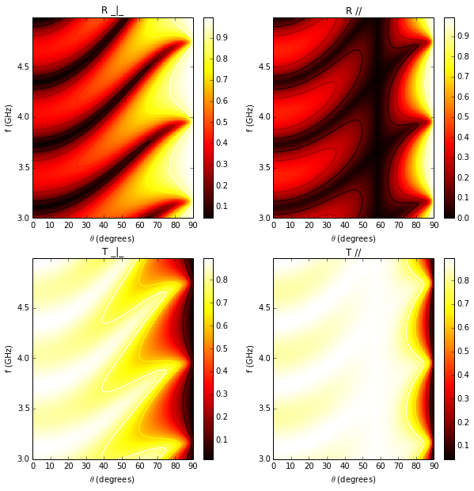

```python
fig = plt.figure(figsize=(10,10))
S['slab2'].pcolor()
```

```python
A=S['slab2']
```

As any PyLayers object there is an help function for remembering which methods are implemented in the class.

```python
A.help()
```

```
clear: D.clear() -> None.  Remove all items from D.
conv:  build lmat and thick
copy: D.copy() -> a shallow copy of D
editgui:  edit a Slab in the DB
ev:  evaluation of the slab
excess_grdelay:  calculate transmission excess delay in ns
filter:  filtering waveform
fromkeys: dict.fromkeys(S[,v]) -> New dict with keys from S and values equal to v.
get: D.get(k[,d]) -> D[k] if k in D, else d.  d defaults to None.
has_key: D.has_key(k) -> True if D has a key k, else False
help:  generic help
info:  Display Slab Info
items: D.items() -> list of D's (key, value) pairs, as 2-tuples
iteritems: D.iteritems() -> an iterator over the (key, value) items of D
iterkeys: D.iterkeys() -> an iterator over the keys of D
itervalues: D.itervalues() -> an iterator over the values of D
keys: D.keys() -> list of D's keys
loss0:  calculate loss for theta=0 at frequency (fGHz)
losst:  Calculate loss w.r.t angle and frequency
pcolor:  display of R & T coefficients wrt frequency an angle
plotwrt:  plot R & T coefficients with respect to angle or frequency
pop: D.pop(k[,d]) -> v, remove specified key and return the corresponding value.
popitem: D.popitem() -> (k, v), remove and return some (key, value) pair as a
setdefault: D.setdefault(k[,d]) -> D.get(k,d), also set D[k]=d if k not in D
show:  show slab Reflection and Transmission coefficient
tocolor:   convert slab properrties into a color
update: D.update([E, ]**F) -> None.  Update D from dict/iterable E and F.
values: D.values() -> list of D's values
viewitems: D.viewitems() -> a set-like object providing a view on D's items
viewkeys: D.viewkeys() -> a set-like object providing a view on D's keys
viewvalues: D.viewvalues() -> an object providing a view on D's values
```

## Information necessary to define a Slab

Each slab contains informations about its constitutive materials electromagnetic properties.

Below an example for a simple slab, constituted with a single material slab. The slab 'WOOD' is a layer of 4cm 'WOOD' material.

```python
S['WOOD']['lmatname']
```

```
['WOOD']
```

thickness is expressed in meters

```python
S['WOOD']['lthick']
```

```
[0.04]
```

```python
S['WOOD']['color']
```

```
'maroon'
```

```python
S['WOOD']['linewidth']
```

```
2
```

Multi layers Slab, using different stacks of materials can be easily defined using the two lists **lmatname** and **lthick**.

> Notice the adopted convention naming lists starting with letter 'l' and dictionnaries starting with letter 'd'

```python
S['3D_WINDOW_GLASS']['lmatname']
```

```
['GLASS', 'AIR', 'GLASS']
```

```python
S['3D_WINDOW_GLASS']['lthick']
```

```
[0.005, 0.005, 0.005]
```

For each constitutive material of a slab, their electromagnetic properties can be obtained as:

```python
S['3D_WINDOW_GLASS']['lmat']
```

```
[{'epr': (3.79999995232+0j),
  'index': 4,
  'mur': (1+0j),
  'name': 'GLASS',
  'roughness': 0.0,
  'sigma': 0.0},
 {'epr': (1+0j),
  'index': 1,
  'mur': (1+0j),
  'name': 'AIR',
  'roughness': 0.0,
  'sigma': 0.0},
 {'epr': (3.79999995232+0j),
  'index': 4,
  'mur': (1+0j),
  'name': 'GLASS',
  'roughness': 0.0,
  'sigma': 0.0}]
```

## Evaluation of a Slab

Each Slab can be evaluated to obtain the Transmission and Reflexion coefficients for

- a given frequency range
- a given incidence angle range ($0\le\theta<\frac{\pi}{2}$)

```python
fGHz = np.arange(3,5,0.01)
theta = np.arange(0,np.pi/2,0.01)

S['WOOD'].ev(fGHz,theta,compensate=True)
sR = np.shape(S['WOOD'].R)
print '\nHere, slab is evaluted for',sR[0],'frequency(ies)', 'and',sR[1], 'angle(s)\n'
```

```
Here, slab is evaluted for 200 frequency(ies) and 158 angle(s)
```

## Transmission and Reflexion coefficients

Reflexion and transmission coefficient are computed for the given frequency range and theta range

```python
ifreq=1
ithet=10

print '\nReflection coefficient @',fGHz[ifreq],'GHz and theta=',theta[ithet],':\n\n R=',S['WOOD'].R[0,0]
print '\nTransmission coefficient @',fGHz[ifreq],'GHz and theta=',theta[ithet],':\n\n T=',S['WOOD'].T[0,0],'\n'
```

```
Reflection coefficient @ 3.01 GHz and theta= 0.1 :

 R= [[-0.39396205-0.17289585j  0.00000000+0.j        ]
 [ 0.00000000+0.j          0.39396205+0.17289585j]]

Transmission coefficient @ 3.01 GHz and theta= 0.1 :

 T= [[-0.17594898-0.86927604j -0.00000000+0.j        ]
 [-0.00000000+0.j         -0.17594898-0.86927604j]]
```

### Ploting Reflection and Transmission Coefficients

The method `plotwrt` can plot the different calculated coefficients with respect to angle or frequency.

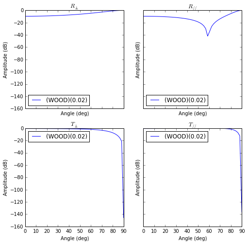

```python
S['WOOD']['lthick']=[0.02]
S['WOOD'].ev()
S['WOOD'].ev()
f,a=S['WOOD'].plotwrt()
```

```python
fGHz = np.arange(1,10,0.01)
theta = np.arange(0,np.pi/2,0.01)

S['3D_WINDOW_GLASS']['lthick']=[0.006,0.01,0.006]
#S['3D_WINDOW_GLASS']['lmatname']=['GLASS','AIR','GLASS']
S['3D_WINDOW_GLASS'].ev(fGHz,theta)
```

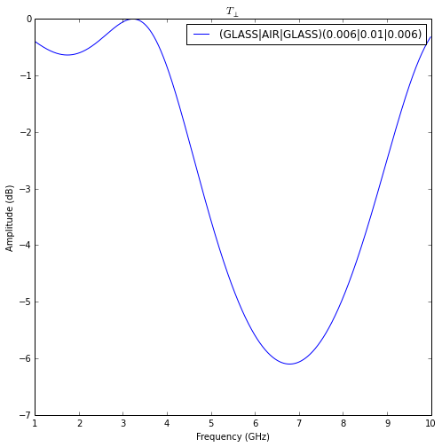

```python
fig,ax = S['3D_WINDOW_GLASS'].plotwrt(var='f',coeff='T',polar='o')
```

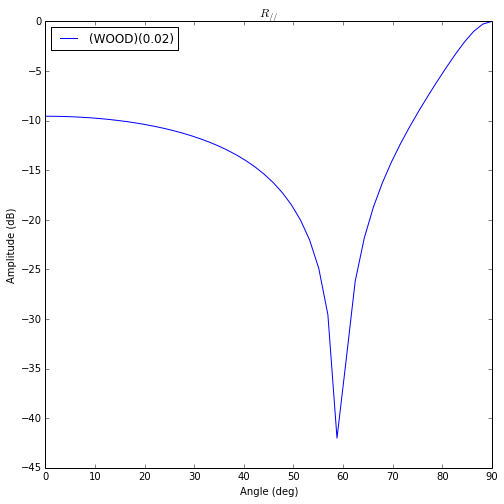

```python
fig,ax = S['WOOD'].plotwrt(var='a',coeff='R',polar='p')
```

plot with respect to angle

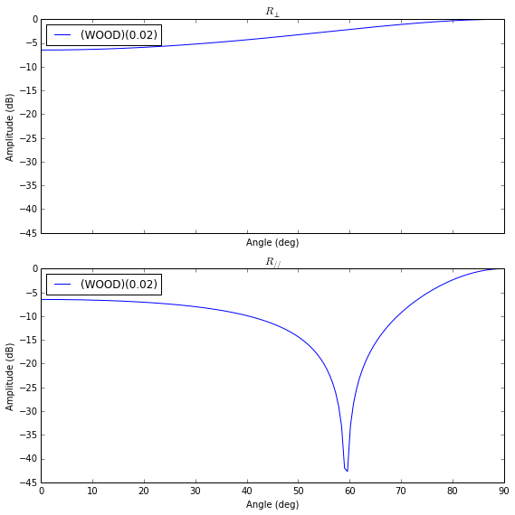

```python
fig = plt.figure(figsize=(20,20))
fGHz= np.array([2.4])
S['WOOD'].ev(fGHz,theta)
fig,ax = S['WOOD'].plotwrt(var='a',coeff='R',fig=fig)
plt.tight_layout()
```

wrt to angle and frequency

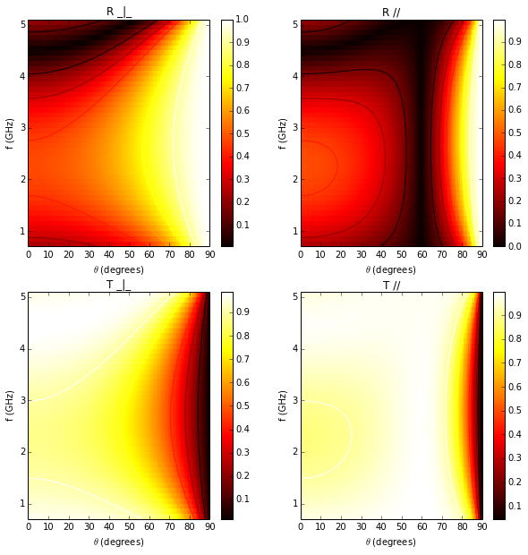

```python
plt.figure(figsize=(10,10))
fGHz= np.arange(0.7,5.2,0.1)
S['WOOD'].ev(fGHz,theta)
S['WOOD'].pcolor()
```

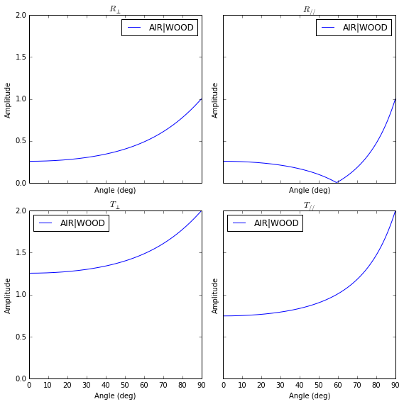

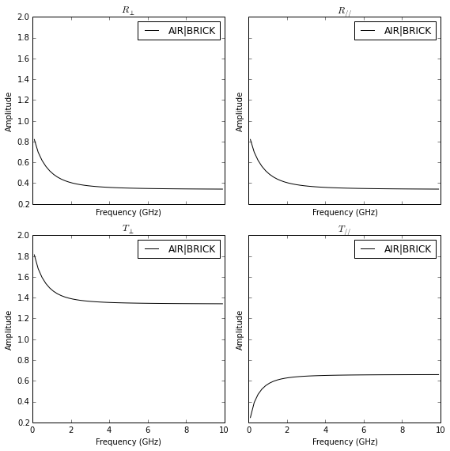

```python
theta = np.arange(0,np.pi/2,0.01)
fGHz = np.arange(0.1,10,0.2)
sl = SlabDB('matDB.ini','slabDB.ini')
mat   = sl.mat
lmat  = [mat['AIR'],mat['WOOD']]
II    = MatInterface(lmat,0,fGHz,theta)
II.RT()
fig,ax = II.plotwrt(var='a',kv=10,typ=['m'])
plt.tight_layout()
air = mat['AIR']
brick  = mat['BRICK']
II  = MatInterface([air,brick],0,fGHz,theta)
II.RT()
fig,ax = II.plotwrt(var='f',color='k',typ=['m'])
plt.tight_layout()
```

[output not shown]

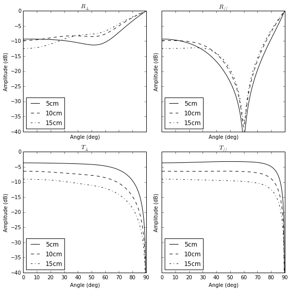

```python
sl.mat.add(name='TESS-p50',cval=3+0j,sigma=0.06,typ='epsr')

sl.add(name='TESS-p50-5cm',lmatname=['TESS-p50'],lthick=[0.05])
sl.add(name='TESS-p50-10cm',lmatname=['TESS-p50'],lthick=[0.10])
sl.add(name='TESS-p50-15cm',lmatname=['TESS-p50'],lthick=[0.15])
fGHz=4
theta = np.arange(0,np.pi/2,0.01)
#figure(figsize=(8,8))
# These Tessereau page 50

sl['TESS-p50-5cm'].ev(fGHz,theta,compensate=True)
sl['TESS-p50-10cm'].ev(fGHz,theta,compensate=True)
sl['TESS-p50-15cm'].ev(fGHz,theta,compensate=True)

# by default var='a' and kv = 0

fig,ax = sl['TESS-p50-5cm'].plotwrt(color='k',labels=['5cm'])
fig,ax = sl['TESS-p50-10cm'].plotwrt(color='k',labels=['10cm'],linestyle='dashed',fig=fig,ax=ax)
fig,ax = sl['TESS-p50-15cm'].plotwrt(color='k',labels=['15cm'],linestyle='dashdot',fig=fig,ax=ax)
plt.axis([0,90,-40,0])
plt.tight_layout()
```

## Evaluation without phase compensation

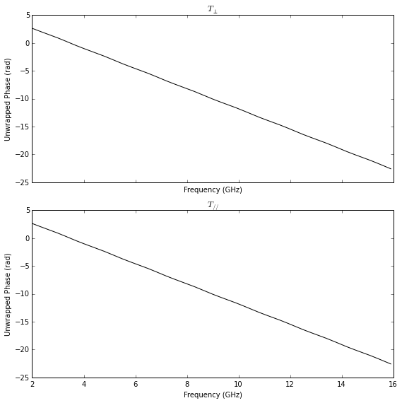

```python
fGHz = np.arange(2,16,0.1)
theta = 0

sl['TESS-p50-5cm'].ev(fGHz,theta,compensate=False)
sl['TESS-p50-10cm'].ev(fGHz,theta,compensate=False)
sl['TESS-p50-15cm'].ev(fGHz,theta,compensate=False)

fig,ax = sl['TESS-p50-5cm'].plotwrt('f',coeff='T',typ=['ru'],labels=[''],color='k')
#print ax
#fig,ax = sl['TESS-p50-10cm'].plotwrt('f',coeff='T',types=['ru'],labels=[''],color='k',linestyle='dashed',fig=fig,ax=ax)
#fig,ax = sl['TESS-p50-15cm'].plotwrt('f',coeff='T',types=['ru'],labels=[''],color='k',linestyle='dashdot')
plt.tight_layout()
```

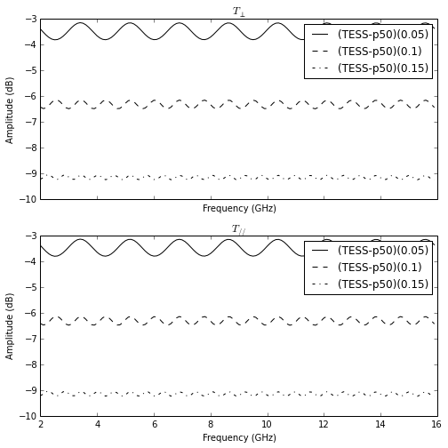

```python
sl['TESS-p50-5cm'].ev(fGHz,theta,compensate=True)
sl['TESS-p50-10cm'].ev(fGHz,theta,compensate=True)
sl['TESS-p50-15cm'].ev(fGHz,theta,compensate=True)

fig,ax = sl['TESS-p50-5cm'].plotwrt('f',coeff='T',typ=['ru'],labels=['5cm compensated',''],color='r',fig=fig,ax=ax)
fig,ax = sl['TESS-p50-10cm'].plotwrt('f',coeff='T',typ=['ru'],labels=['10cm compensated',''],color='r',linestyle='dashed',fig=fig,ax=ax)
fig,ax = sl['TESS-p50-15cm'].plotwrt('f',coeff='T',typ=['ru'],labels=['15cm not compensated',''],color='r',linestyle='dashdot',fig=fig,ax=ax)

fig,ax = sl['TESS-p50-5cm'].plotwrt('f',coeff='T',color='k')
fig,ax = sl['TESS-p50-10cm'].plotwrt('f',coeff='T',color='k',linestyle='dashed',fig=fig,ax=ax)
fig,ax = sl['TESS-p50-15cm'].plotwrt('f',coeff='T',color='k',linestyle='dashdot',fig=fig,ax=ax)
```

## Double Glass example from litterature [1] in sub TeraHertz D-band @ 120GHz

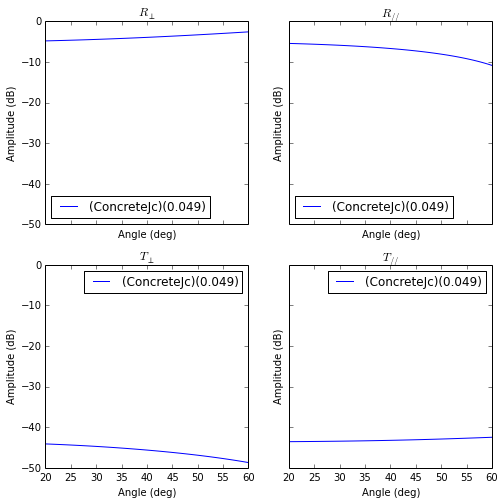

```python
sl.mat.add('ConcreteJc',cval=3.5,alpha_cmm1=1.9,fGHz=120,typ='THz')
sl.mat.add('GlassJc',cval=2.55,alpha_cmm1=2.4,fGHz=120,typ='THz')
sl.add('ConcreteJc',['ConcreteJc'],[0.049])

theta = np.linspace(20,60,100)*np.pi/180
sl['ConcreteJc'].ev(120,theta)
fig,ax = sl['ConcreteJc'].plotwrt('a')
```

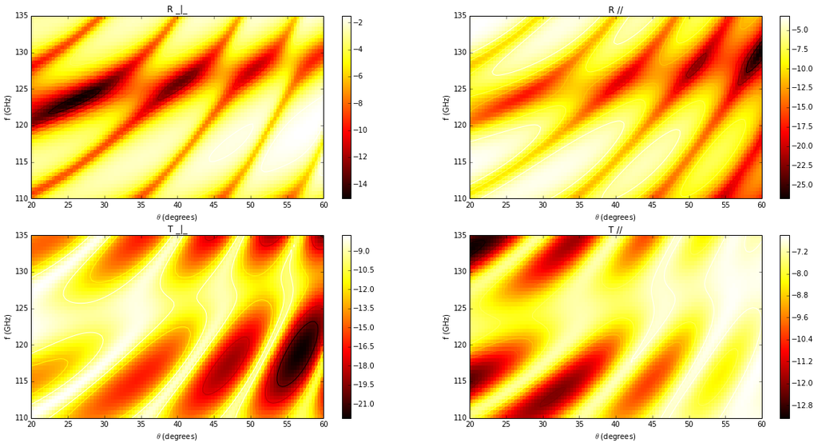

```python
plt.figure(figsize=(20,10))
fGHz = np.linspace(110,135,50)
sl.add('DoubleGlass',['GlassJc','AIR','GlassJc'],[0.0029,0.0102,0.0029])
sl['DoubleGlass'].ev(fGHz,theta)
sl['DoubleGlass'].pcolor(dB=True)
```

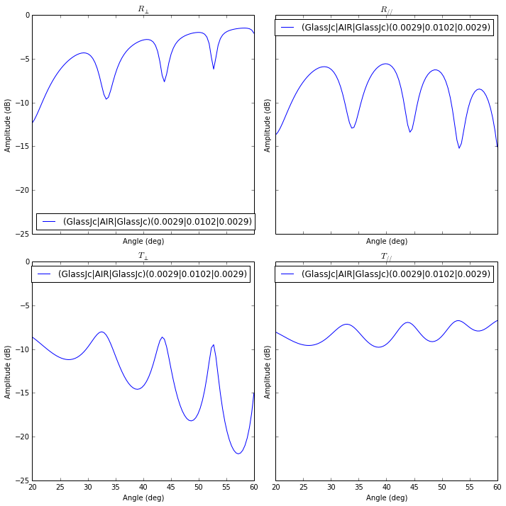

```python
f = plt.figure(figsize=(4,4))
f = sl['DoubleGlass'].ev(120,theta)
fig,ax = sl['DoubleGlass'].plotwrt('a',figsize=(10,10))
plt.tight_layout()
```

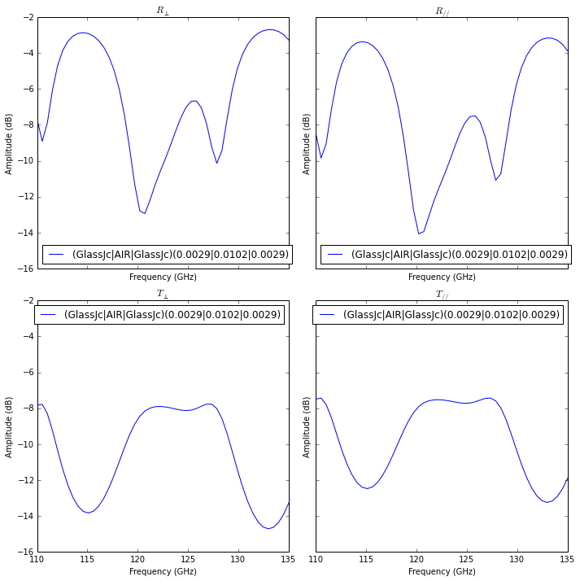

```python
freq = np.linspace(110,135,50)
sl['DoubleGlass'].ev(freq,theta)
fig,ax = sl['DoubleGlass'].plotwrt('f',figsize=(10,10))  # @20°
plt.tight_layout()
```

## References

[1]. Jacob, M. ; Kurner, T. ; Geise, R. ; Piesiewicz, R. "Reflection ant Transmission Properties of Building Materials in D-Band for Modeling Future mm-Wave Communication Systems" Antennas and Propagation (EuCAP), 2010 Proceedings of the Fourth European Conference on

[2]. R.Piesiewicz 'Terahertz characterization of building materials' Electronics .Letters Jan 2005 Vol 41 N°18